# Equality in access to and participation in parkrun events in England over time

2020-06-05

**Robert Smith**<sup>1</sup>  
**Paul Schneider**<sup>1</sup>

<sup>1</sup>*ScHARR, University of Sheffield*

#### Objectives of this analysis:

1. To better understand how access to and participation in parkrun events in England evolved over time
2. Study the socioeconomic gradient in access and participation over time

## INTRODUCTION

Our previous analysis published in [Wellcome Open Research](https://wellcomeopenresearch.org/articles/5-9) used data from 2018 to investigate parkrun participation at one point in time. We found that participation in parkrun was much **worse** in areas with high levels of deprivation than areas with low levels of deprivation. This effect was shown to persist, even when controlling for ethnic density. However, in another study we found that that those living in more deprived areas tend to have **better** geographic access to parkrun than those living in less deprived areas [Schneider et al., 2019](https://www.medrxiv.org/content/10.1101/19004143v1).

parkrun’s Health and Wellbeing team were particularly interested in these studies, since they aim to “promote participation by those who are least active and/or have lower levels of health” [parkrunBlog](https://blog.parkrun.com/uk/2018/04/25/a-healthier-and-happier-planet/), in particular targeting more deprived communities [Sport England](https://blog.parkrun.com/uk/2018/12/12/sportenglandfunding/). They requested that we use historical data to investigate the trends in the efficiency (overall) and equity (between groups) of access and participation.

## ANALYSIS

#### Preparation

First of all, we clean the R environment and install, if necessary, and load the packages that are required for the analysis.

```r
# clean the R enviroment
rm(list=ls())
```

```r
# Load the required packages
library(dplyr)       # for use of pipes
library(reshape2)    # to transform from wide-long long-wide
library(data.table)  # faster carpentry.
# library(date)
library(raster)
library(geosphere) # used to find geodesic distances
library(ggplot2)   # to make plots
library(scales)    # to make plots
library(RColorBrewer) # to make plots
```

#### Data sets

The following data sets are used for the analysis:

Name | Source | Description |  
——– |:——— :| :——— |  
participation | parkrunUK | number of parkrun finishes by LSOA and week from 01/01/2010 to 28/12/2019 |  
events | parkrunUK | location and date each event established |  
imd | ONS | 2015 Index of Multiple Deprivation scores by LSOA |  
centroids | ONS | Population-weighted LSOA centroids and total population|

We obtained data from parkrunUK on the number of finishers each week from each LSOA in England from 2010-2019. We combined this with data from the parkrun website which provides the location and date of every parkrun event in the country.

We also obtained IMD scores and deciles for each of the 32,844 LSOAs in England from the ONS, and combined this with the location of the population weighted geographic centroids and total population of the LSOA.

This meant that for each LSOA we have the number of finishes per week, the IMD score & decile, population and the location coordinates of the geographic centroid.

For each parkrun event we have the location coordinates of the event, and the date in which the first event took place.

##### Read in the data

Read in the raw data, clean and prepare

```r
# 1. Parkrun participation data
  # read in parkrun participation data
  runs_df = readRDS("./runs_per_lsoa_2010to2020.Rds")
  # participation is measured in n of idividuals who finish a parkrun event
  head(runs_df) # take a look at the data set
```

| date | lsoa | finishers |
| --- | --- | --- |
| 2011-10-08 | E01032408 | 1 |
| 2011-10-08 | S01000002 | 1 |
| 2011-10-08 | S01000012 | 1 |
| 2011-10-08 | S01000015 | 2 |
| 2011-10-08 | S01000016 | 1 |
| 2011-10-08 | S01000019 | 1 |

```r
  dim(runs_df) # it is quite huge
```

```
## [1] 9313529       3
```

```r
  runs_df = as.data.table(runs_df) # we use data.table to speed up the analysis
  runs_df$date = as.Date(unclass(runs_df$date),format="%Y-%m-%d") # convert to Date class

  # Clean
  runs_df = runs_df[grep(pattern = "E",runs_df$lsoa),] # select LSOAs in England
  runs_df = runs_df[runs_df$date <= as.Date("2018-12-12"),] # select runs up until 2018-12-12

  # We will analyse the data on the monthly level, so
  # we need to create  a year+month variable:
  runs_df$month_year = substr(runs_df$date,1,7)
  head(runs_df)
```

| date | lsoa | finishers | month_year |
| --- | --- | --- | --- |
| 2011-10-08 | E01032408 | 1 | 2011-10 |
| 2011-10-15 | E01001949 | 1 | 2011-10 |
| 2011-10-15 | E01025453 | 1 | 2011-10 |
| 2011-10-22 | E01002948 | 1 | 2011-10 |
| 2011-10-22 | E01029276 | 1 | 2011-10 |
| 2011-10-29 | E01029276 | 1 | 2011-10 |

```r
# 2. parkrun event locations
  # read in data
  event_locations = read.csv("./event_info_20181212.csv")
  event_locations$month_year = substr(event_locations$Estblsh,1,7)
  event_locations$Estblsh = as.Date(event_locations$Estblsh)
  head(event_locations[,1:4])
```

|  | course | lng | lat | Estblsh |
| --- | --- | --- | --- | --- |
| 1 | brooklands | 0.543354 | 51.34696 | 2018-11-17 |
| 2 | fletchermoss | -2.231866 | 53.40925 | 2018-11-17 |
| 3 | henleywood | -3.030152 | 52.86277 | 2018-10-20 |
| 4 | jerseyfarm | -0.308582 | 51.77310 | 2018-11-10 |
| 5 | marketrasenracecourse | -0.315743 | 53.38151 | 2018-11-03 |
| 6 | myrtle | -1.841101 | 53.84633 | 2018-11-03 |

```r
# 3. 2015 IMD data
  # Read in IMD scores
  lsoa_imd = read.csv("./IMD_data.csv")
  head(lsoa_imd) # take a look at the raw data
```

|  | LSOA.code..2011. | LSOA.name..2011. | Local.Authority.District.code..2013. | Local.Authority.District.name..2013. | Index.of.Multiple.Deprivation..IMD..Score | Index.of.Multiple.Deprivation..IMD..Rank..where.1.is.most.deprived. | Index.of.Multiple.Deprivation..IMD..Decile..where.1.is.most.deprived.10..of.LSOAs. | Income.Score..rate. | Income.Rank..where.1.is.most.deprived. | Income.Decile..where.1.is.most.deprived.10..of.LSOAs. | Employment.Score..rate. | Employment.Rank..where.1.is.most.deprived. | Employment.Decile..where.1.is.most.deprived.10..of.LSOAs. | Education..Skills.and.Training.Score | Education..Skills.and.Training.Rank..where.1.is.most.deprived. | Education..Skills.and.Training.Decile..where.1.is.most.deprived.10..of.LSOAs. | Health.Deprivation.and.Disability.Score | Health.Deprivation.and.Disability.Rank..where.1.is.most.deprived. | Health.Deprivation.and.Disability.Decile..where.1.is.most.deprived.10..of.LSOAs. | Crime.Score | Crime.Rank..where.1.is.most.deprived. | Crime.Decile..where.1.is.most.deprived.10..of.LSOAs. | Barriers.to.Housing.and.Services.Score | Barriers.to.Housing.and.Services.Rank..where.1.is.most.deprived. | Barriers.to.Housing.and.Services.Decile..where.1.is.most.deprived.10..of.LSOAs. | Living.Environment.Score | Living.Environment.Rank..where.1.is.most.deprived. | Living.Environment.Decile..where.1.is.most.deprived.10..of.LSOAs. | Income.Deprivation.Affecting.Children.Index..IDACI..Score..rate. | … |
| --- | --- | --- | --- | --- | --- | --- | --- | --- | --- | --- | --- | --- | --- | --- | --- | --- | --- | --- | --- | --- | --- | --- | --- | --- | --- | --- | --- | --- | --- | --- |
| 1 | E01031349 | Adur 001A | E07000223 | Adur | 12.389 | 21352 | 7 | 0.096 | 18992 | 6 | 0.083 | 19305 | 6 | 20.055 | 13727 | 5 | -0.718 | 25876 | 8 | 0.242 | 12817 | 4 | 10.586 | 28166 | 9 | 15.180 | 18367 | 6 | 0.143 | … |
| 2 | E01031350 | Adur 001B | E07000223 | Adur | 28.619 | 8864 | 3 | 0.187 | 9233 | 3 | 0.162 | 7879 | 3 | 34.653 | 6969 | 3 | 0.722 | 6883 | 3 | 0.244 | 12781 | 4 | 24.689 | 11399 | 4 | 17.837 | 16242 | 5 | 0.211 | … |
| 3 | E01031351 | Adur 001C | E07000223 | Adur | 11.713 | 22143 | 7 | 0.065 | 24539 | 8 | 0.066 | 23389 | 8 | 26.334 | 10213 | 4 | -0.616 | 24693 | 8 | 0.495 | 9112 | 3 | 13.631 | 24743 | 8 | 11.150 | 22299 | 7 | 0.077 | … |
| 4 | E01031352 | Adur 001D | E07000223 | Adur | 16.446 | 17252 | 6 | 0.117 | 16087 | 5 | 0.113 | 13699 | 5 | 25.779 | 10468 | 4 | -0.234 | 19627 | 6 | 0.026 | 16127 | 5 | 17.803 | 19559 | 6 | 10.677 | 22819 | 7 | 0.210 | … |
| 5 | E01031370 | Adur 001E | E07000223 | Adur | 18.265 | 15643 | 5 | 0.102 | 17918 | 6 | 0.115 | 13322 | 5 | 32.056 | 7819 | 3 | 0.082 | 14893 | 5 | 0.182 | 13723 | 5 | 15.482 | 22433 | 7 | 15.378 | 18191 | 6 | 0.117 | … |
| 6 | E01031374 | Adur 001F | E07000223 | Adur | 12.529 | 21176 | 7 | 0.072 | 23201 | 8 | 0.084 | 18948 | 6 | 14.261 | 18006 | 6 | -0.183 | 18846 | 6 | 0.128 | 14566 | 5 | 15.696 | 22170 | 7 | 22.053 | 13264 | 5 | 0.060 | … |

```r
  # remove columns we dont need and rename the one we do need
  lsoa_imd = lsoa_imd %>% # read csv
    dplyr::select(c("LSOA.code..2011.","Index.of.Multiple.Deprivation..IMD..Score", # select relevant colums
             "Index.of.Multiple.Deprivation..IMD..Decile..where.1.is.most.deprived.10..of.LSOAs.",
             "Total.population..mid.2012..excluding.prisoners.")) %>%
    'colnames<-'(c("lsoa","imd_score","imd_decile","total_pop")) # rename columns
  head(lsoa_imd) # take a look at the clean data set
```

|  | lsoa | imd_score | imd_decile | total_pop |
| --- | --- | --- | --- | --- |
| 1 | E01031349 | 12.389 | 7 | 1318 |
| 2 | E01031350 | 28.619 | 3 | 1212 |
| 3 | E01031351 | 11.713 | 7 | 1577 |
| 4 | E01031352 | 16.446 | 6 | 1453 |
| 5 | E01031370 | 18.265 | 5 | 1443 |
| 6 | E01031374 | 12.529 | 7 | 1499 |

```r
# 4. LSOA pop-weighted centroid locations
  # read in shape file
  lsoa_locations = shapefile("./England_lsoa_2011_centroids/england_lsoa_2011_centroids.shp")
  # use correct projection
  lsoa_locations = spTransform(lsoa_locations,crs("+proj=longlat +datum=WGS84 +no_defs +ellps=WGS84 +towgs84=0,0,0"))
  # extract coordinates
  lsoa_centr = coordinates(lsoa_locations)
  rownames(lsoa_centr) = lsoa_locations$code
```

#### Variables of interest

There are several variables which are used throughout the analysis:

1. **parkrun participation**: participation is measured by the number of finishers in a specified time period. This includes only those individuals who complete an event and scan their bar-code. It may therefore be a (slight) underestimate of total participation.
2. **Distance to the nearest event**: The access of the population living in a given LSOA is measured as the geodesic distance (this is distance as the crow flies) between the LSOA’s population-weighted centroid and the nearest active (in existance) parkrun event.
3. **Index of multiple deprivation (IMD)**: The score combines indices from seven domains (health, education, barriers to horsing and services, crime and living environment), Higher score indicate higher levels of deprivation. For the analysis, we will mainly use IMD deciles: i.e. look at the top and bottom 10% LSOAs.
4. **Slope index of inequality**: used for access. The Slope Index of Inequality is commonly used to give an indication of the difference in life expectancy between more and less deprived areas. We apply it here as a measure of inequality of access to parkrun.
5. **Relative index of inequality**: used for participation. The Relative Index of Inequality is commonly used to provide an indication of the relative inequality between more and less deprived areas. We apply it here as a measure of relative inequality of participation in parkrun.

```r
# 1. parkrun participation

  # aggregate by lsoa and year (fast version using data.table)
  monthly_runs = runs_df[, lapply(.SD, sum), by = month_year, .SDcols = "finishers"]

  monthly_runs_by_lsoa = runs_df[, lapply(.SD, sum), by = c("month_year","lsoa"), .SDcols = "finishers"]

# Before we proceed with the analysis of socio economic disparities,
  # we need to account for the missing data
  # LSOAs with no runs are not in the data
  # (some lsoas might even be missing completely, if they never had a participant)
  # so we have to fill them in manually:
  fill_dat = expand.grid(unique(monthly_runs_by_lsoa$month_year),
                         lsoa_imd$lsoa) # using all English LSOAs from the imd data set
  names(fill_dat) = c("month_year","lsoa")
  fill_dat = data.table(fill_dat)
  monthly_runs_by_lsoa = merge(fill_dat,monthly_runs_by_lsoa,by=c("month_year","lsoa"),all.x=T)
  monthly_runs_by_lsoa$finishers[is.na(monthly_runs_by_lsoa$finishers)] = 0  # filling missings
  dim(monthly_runs_by_lsoa) # now we have quite a big data set
```

```
## [1] 3547152       3
```

```r
  head(monthly_runs_by_lsoa)
```

| month_year | lsoa | finishers |
| --- | --- | --- |
| 2010-01 | E01000001 | 0 |
| 2010-01 | E01000002 | 0 |
| 2010-01 | E01000003 | 0 |
| 2010-01 | E01000005 | 0 |
| 2010-01 | E01000006 | 0 |
| 2010-01 | E01000007 | 0 |

```r
  # proportion of LSOAs that had 0 runs in any given months
  monthly_runs_by_lsoa[, lapply(.SD, function(x){round(sum(x==0)/length(x),4)*100}), by = c("month_year"), .SDcols = "finishers"]
```

| month_year | finishers |
| --- | --- |
| 2010-01 | 94.27 |
| 2010-02 | 93.38 |
| 2010-03 | 92.93 |
| 2010-04 | 92.09 |
| 2010-05 | 90.09 |
| 2010-06 | 90.80 |
| 2010-07 | 89.82 |
| 2010-08 | 89.51 |
| 2010-09 | 89.26 |
| 2010-10 | 88.09 |

[output cut: 98 more lines]

```r
# 2. Access (= distance to the nearst parkrun event)
  # compute the distances between all 32,844 lsoas and all 465 parkrun events
  # CAVE: computationally heavy computation!
  distM = geosphere::distm(x= lsoa_locations,y=cbind(event_locations$lng,event_locations$lat))
  rownames(distM) = rownames(lsoa_centr)
  colnames(distM) = event_locations$course
  # custom function to determine the distance to the nearest parkrun event
  # for any given month
  get_min_dist = function(available_event_cols = T,distance_matrix  = distM,month_year="2010-01"){
     Mat = distance_matrix[,available_event_cols]
     min_dist = apply(Mat,1,min)
     min_dist_df = data.frame(lsoa = rownames(Mat),month_year=month_year,access=min_dist)
     return(min_dist_df)
  }


  ## loop to assess access in any given month  (month_years)
  # (may take a while to run)
  distance.df = c()
  months_t = as.Date(paste(unique(monthly_runs_by_lsoa$month_year),"-01",sep=""))
  months_t = seq(from=min(months_t),max(months_t) ,by="months")+14 # for simplicity we look at middle of the month

  for(t in months_t){
      t = as.Date(t, origin = as.Date("1970-01-01"))
      # cat("\r  at:",as.character(t))
      events_in_operation = event_locations$Estblsh <= t # which parkrun events were active in month t?
      temp.dist = get_min_dist(available_event_cols = events_in_operation,month_year = substr(t,1,7))
      distance.df = rbind(distance.df,temp.dist)
    }

  head(distance.df)
```

|  | lsoa | month_year | access |
| --- | --- | --- | --- |
| E01012007 | E01012007 | 2010-01 | 2143.348 |
| E01012085 | E01012085 | 2010-01 | 2652.035 |
| E01012005 | E01012005 | 2010-01 | 14903.309 |
| E01012084 | E01012084 | 2010-01 | 2735.301 |
| E01012002 | E01012002 | 2010-01 | 14159.615 |
| E01012083 | E01012083 | 2010-01 | 2064.420 |

```r
  dim(distance.df)
```

```
## [1] 3547152       3
```

```r
  # merge
  distance.df = data.table(distance.df)
  monthly_runs_by_lsoa = merge(monthly_runs_by_lsoa,distance.df,by=c("lsoa","month_year"),all.x=T)


# 3. now we cmobine the data set with information on LSOA IMD deciles
  lsoa_imd = data.table(lsoa_imd)
  monthly_runs_by_lsoa = merge(monthly_runs_by_lsoa,lsoa_imd,by="lsoa")
  # length(unique(monthly_runs_by_lsoa$lsoa))

# 4. the SII will be computed later on - see below
```

## RESULTS

### Q1: Access to and participation in parkrun events in England over time

#### Access over time

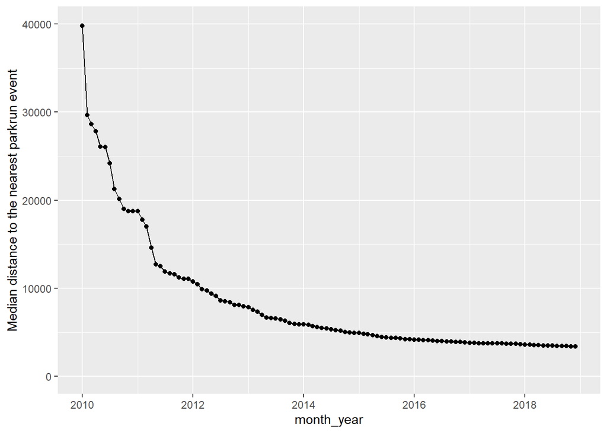

```r
# median distance to the nearets event over time
access_ts = monthly_runs_by_lsoa[, lapply(.SD, median), by = month_year, .SDcols = "access"]
access_ts$month_year = as.Date(paste(access_ts$month_year,"-01",sep=""))
ggplot(access_ts,aes(x=month_year,y=access)) +
  geom_point() +
  geom_line() +
  ylim(c(0,40000)) +
  ylab("Median distance to the nearest parkrun event")
```

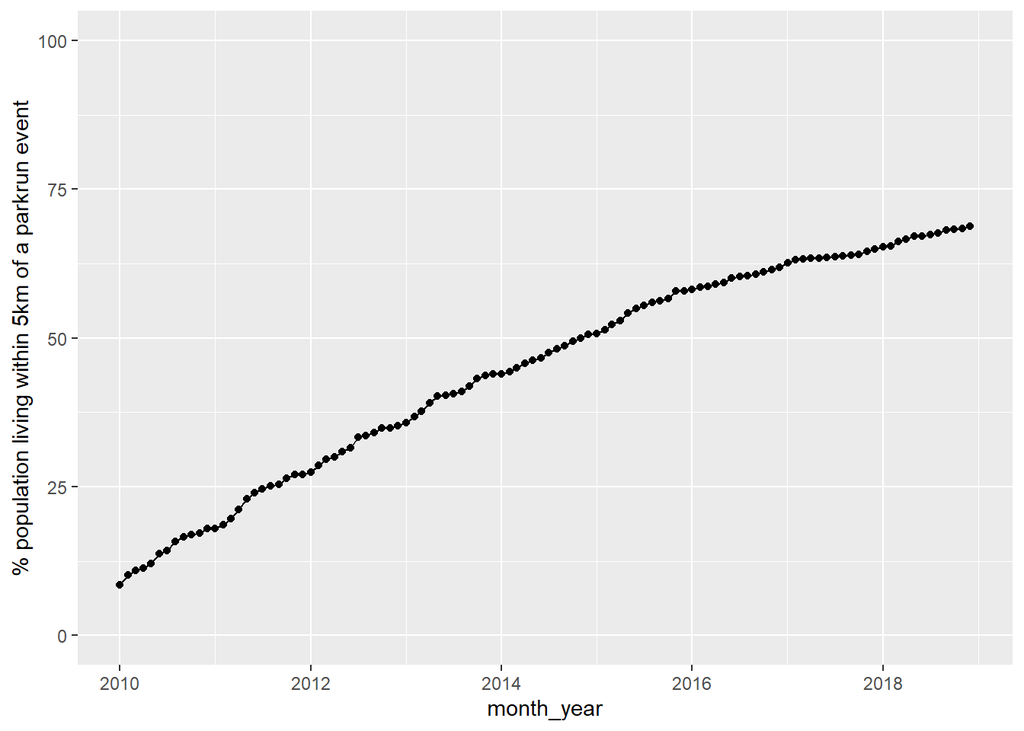

```r
# % population living within 5km of a parkrun event
access_prop_ts = monthly_runs_by_lsoa[, lapply(.SD, function(x){sum(x<=5000)/length(x)}), by = month_year, .SDcols = "access"]
access_prop_ts$month_year = as.Date(paste(access_prop_ts$month_year,"-01",sep=""))
ggplot(access_prop_ts,aes(x=month_year,y=access*100)) +
  geom_point() +
  geom_line() +
  ylim(c(0,100)) +
  ylab("% population living within 5km of a parkrun event")
```

#### Participation over time

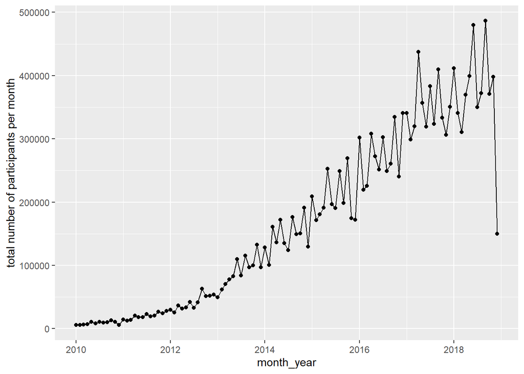

```r
# total participants per month across England
runs_ts_sum = monthly_runs_by_lsoa[, lapply(.SD, sum), by = month_year, .SDcols = "finishers"]
runs_ts_sum$month_year = as.Date(paste(runs_ts_sum$month_year,"-01",sep=""))
ggplot(runs_ts_sum,aes(x=month_year,y=finishers)) +
  geom_point() +
  geom_line() +
  ylab("total number of participants per month")
```

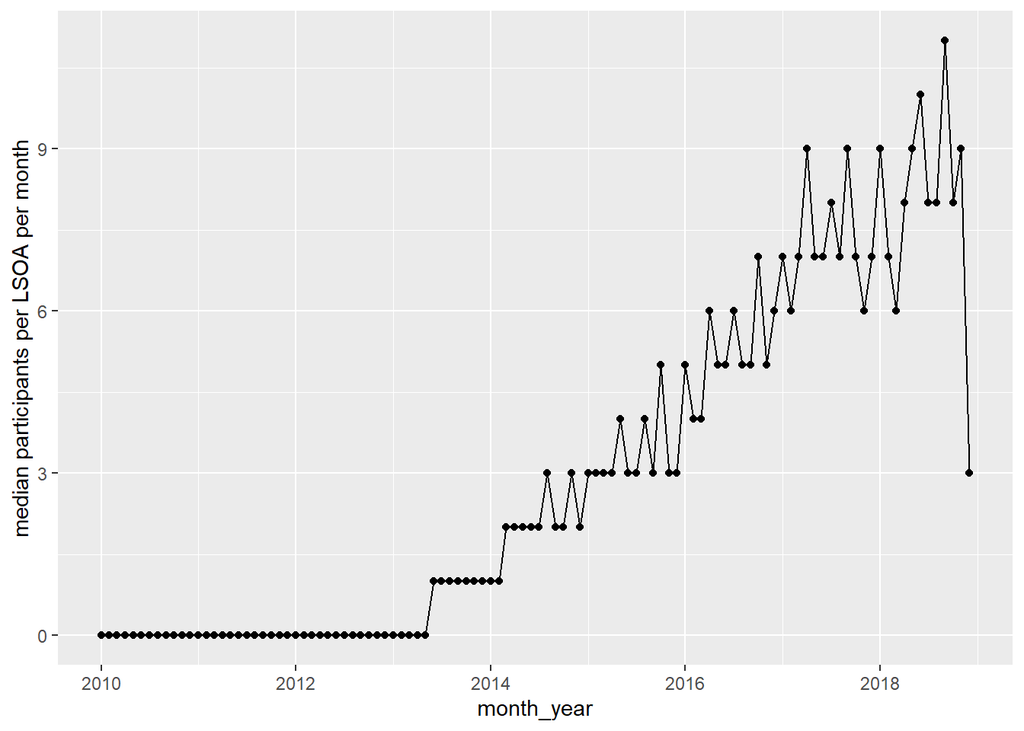

```r
# median participants per LSOA per month
runs_ts_med = monthly_runs_by_lsoa[, lapply(.SD, median), by = month_year, .SDcols = "finishers"]
runs_ts_med$month_year = as.Date(paste(runs_ts_med$month_year,"-01",sep=""))
ggplot(runs_ts_med,aes(x=month_year,y=finishers)) +
  geom_point() +
  geom_line() +
  ylab("median participants per LSOA per month")
```

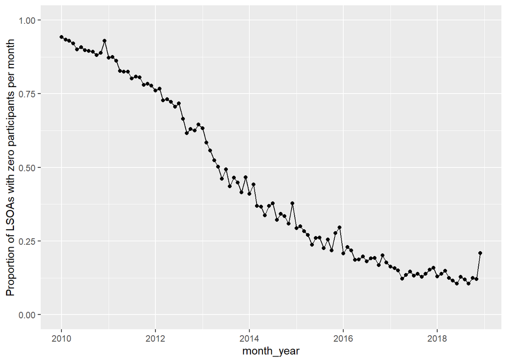

```r
  # total participants per month across England
runs_ts_zero = monthly_runs_by_lsoa[, lapply(.SD, function(x){sum(x==0)/length(x)}), by = month_year, .SDcols = "finishers"]
runs_ts_zero$month_year = as.Date(paste(runs_ts_zero$month_year,"-01",sep=""))
ggplot(runs_ts_zero,aes(x=month_year,y=finishers)) +
  geom_point() +
  geom_line()+
  ylab("Proportion of LSOAs with zero participants per month") +
  ylim(c(0,1))
```

### Q2: The socioeconomic gradient in access and participation over time

#### The socioeconomic gradient in access over time

[figure not shown]

```r
access_by_imd = monthly_runs_by_lsoa[, lapply(.SD, median), by = c("month_year","imd_decile"), .SDcols = "access"]
access_by_imd$month_year = as.Date(paste(access_by_imd$month_year,"-01",sep=""))

imd_colors = brewer.pal(10, "RdYlGn")
imd_labels = c(c("Most deprived",paste(9:6,"th decile",sep=""),"Median",paste(4:2,"th decile",sep=""),"Least deprived"))

# median distance to the nearest event by imd decile
ggplot(access_by_imd,aes(x=month_year,y=access,col=as.factor(imd_decile),group=imd_decile)) +
  # geom_point() +
  geom_line() +
  scale_color_manual(values = imd_colors,name="IMD decile",labels=imd_labels) +
  scale_x_date(date_breaks = "1 year",date_labels = "%Y") +
  ylim(c(0,50000)) +
  ylab("Median distance to the nearest parkrun event") +
  theme_minimal() +
  theme(axis.text.x = element_text(angle=35))
```

```r
# Compute the ratio between the top and bottom IMD median distance ratio
access_by_imd_tb = dcast(data = access_by_imd,formula = month_year ~ imd_decile) %>%
  mutate(RII = `10` / `1`) %>%
    dplyr::select(month_year, RII)
```

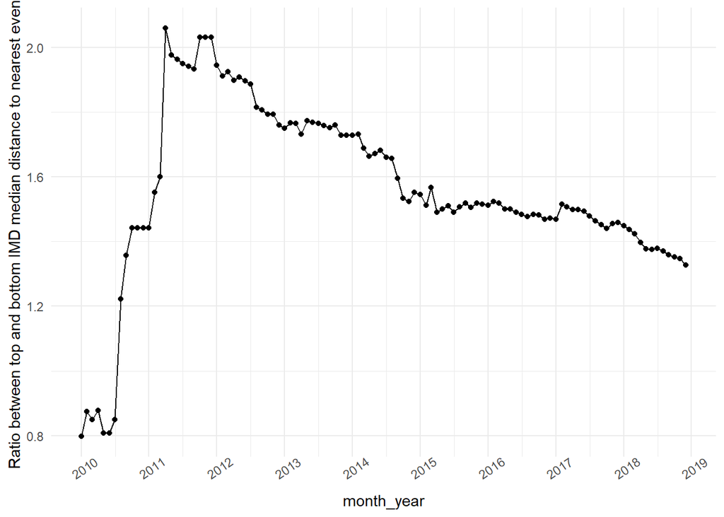

```r
ggplot(access_by_imd_tb,aes(x=month_year,y=RII)) +
  geom_point() +
  geom_line() +
  # scale_color_manual(values = imd_colors,name="IMD decile",labels=imd_labels) +
  scale_x_date(date_breaks = "1 year",date_labels = "%Y") +
  ylab("Ratio between top and bottom IMD median distance to nearest event") +
  theme_minimal() +
  theme(axis.text.x = element_text(angle=35))
```

#### The slope index of inequality in access over time

```r
# max and min IMD
imd_range =  c(max(monthly_runs_by_lsoa$imd_score),min(monthly_runs_by_lsoa$imd_score))

# Slope index of inequality - Example
temp = monthly_runs_by_lsoa[month_year=="2018-08", ]
lm.temp = lm(access ~ imd_score,temp)
pred.temp = predict(lm.temp,newdata = data.frame(imd_score = imd_range))
tb_ratio.temp = pred.temp[2] / pred.temp[1]
tb_ratio.temp
```

```
##        2
## 2.983302
```

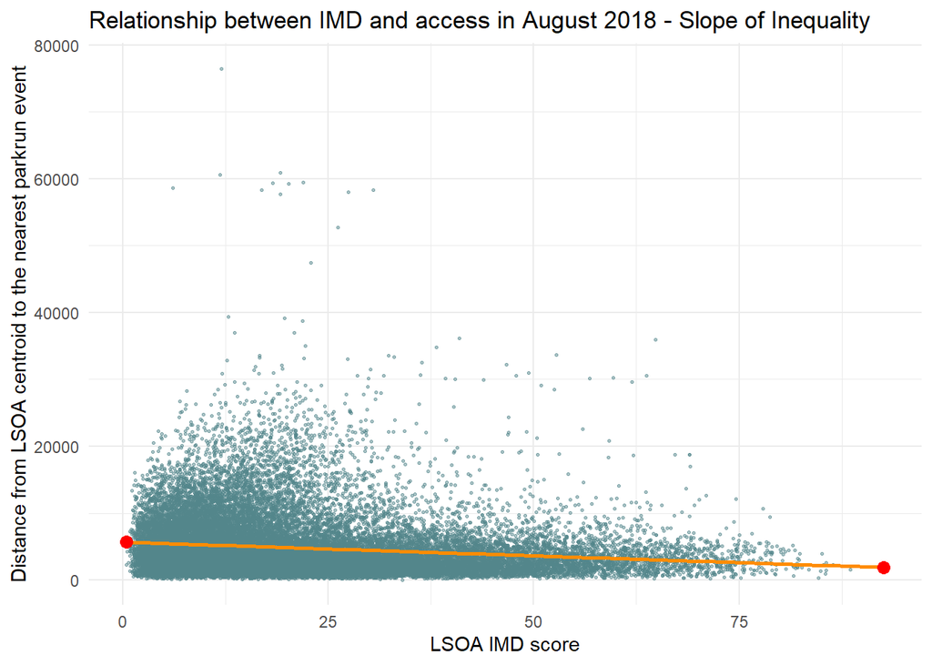

```r
ggplot() +
  geom_point(data=temp,aes(x=imd_score,y=access),alpha=0.5,size=0.5,col="cadetblue4") +
  geom_smooth(data=temp,aes(x=imd_score,y=access),col="darkorange",method="lm",se=F) +
  geom_point(aes(x=imd_range,y=pred.temp),size=3,col="red") +
  ylab("Distance from LSOA centroid to the nearest parkrun event") +
  xlab("LSOA IMD score") +
  ggtitle("Relationship between IMD and access in August 2018 - Slope of Inequality") +
  theme_minimal()
```

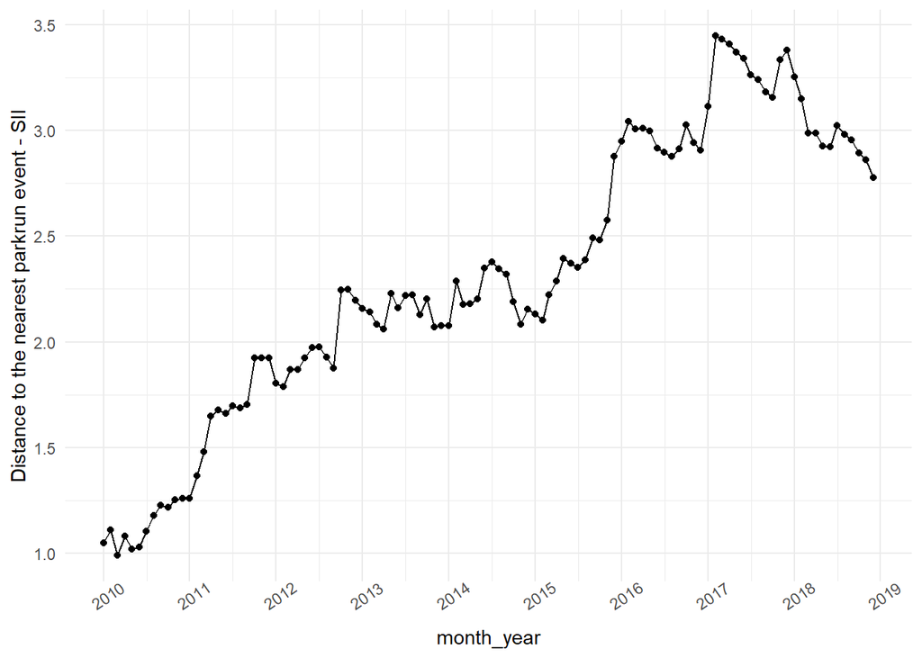

```r
# Loop for all months
uniq.months = unique(monthly_runs_by_lsoa$month_year)
si_access_ts = c()
for(m in uniq.months){
  # cat("\r",m)
  temp = monthly_runs_by_lsoa[month_year==m, ]
  lm.temp = lm(access ~ imd_score,temp)
  pred.temp = predict(lm.temp,newdata = data.frame(imd_score = imd_range))
  tb_ratio.temp = pred.temp[2] / pred.temp[1]
  res.df.temp = data.frame(sii = tb_ratio.temp,month_year=m)
  si_access_ts = rbind(si_access_ts,res.df.temp)
}

si_access_ts$month_year = as.Date(paste(si_access_ts$month_year,"-01",sep=""))
ggplot(si_access_ts,aes(x=month_year,y=sii)) +
  geom_point() +
  geom_line() +
  scale_x_date(date_breaks = "1 year",date_labels = "%Y") +
  ylab("Distance to the nearest parkrun event - SII") +
  theme_minimal() +
  theme(axis.text.x = element_text(angle=35))
```

**Conclusion: bottom has gained better access over time, only from 2017 onwards, inequality started to decrease**

#### The socioeconomic gradient in participation over time

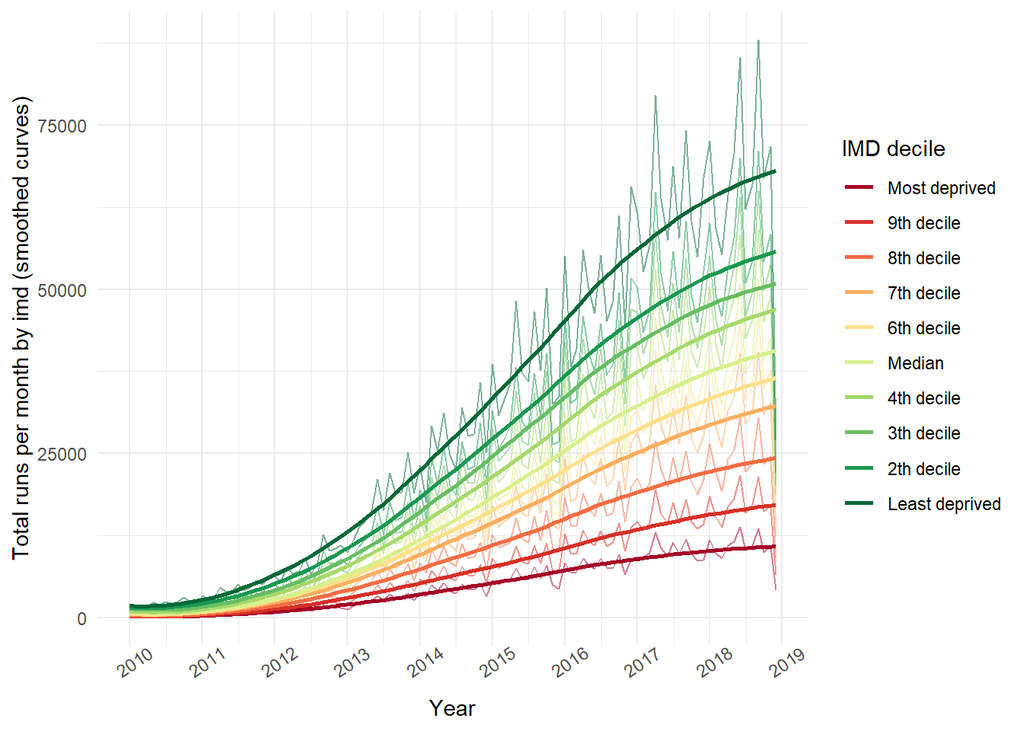

```r
# total (sum) participation by imd group
runs_by_imd = monthly_runs_by_lsoa[, lapply(.SD, sum), by = c("month_year","imd_decile"), .SDcols = "finishers"]
runs_by_imd$month_year = as.Date(paste(runs_by_imd$month_year,"-01",sep=""))

imd_colors = brewer.pal(10, "RdYlGn")
imd_labels = c(c("Most deprived",paste(9:6,"th decile",sep=""),"Median",paste(4:2,"th decile",sep=""),"Least deprived"))

# median distance to the nearest event by imd decile
ggplot(runs_by_imd,aes(x=month_year,y=finishers,col=as.factor(imd_decile),group=imd_decile)) +
  # geom_point() +
  geom_line(size=0.5,alpha=0.5) +
  geom_smooth(se=F) +
  scale_color_manual(values = imd_colors,name="IMD decile",labels=imd_labels) +
  scale_x_date(date_breaks = "1 year",date_labels = "%Y") +
  ylab("Total runs per month by imd (smoothed curves)") +
  xlab("Year") +
  theme_minimal() +
  theme(axis.text.x = element_text(angle=35))
```

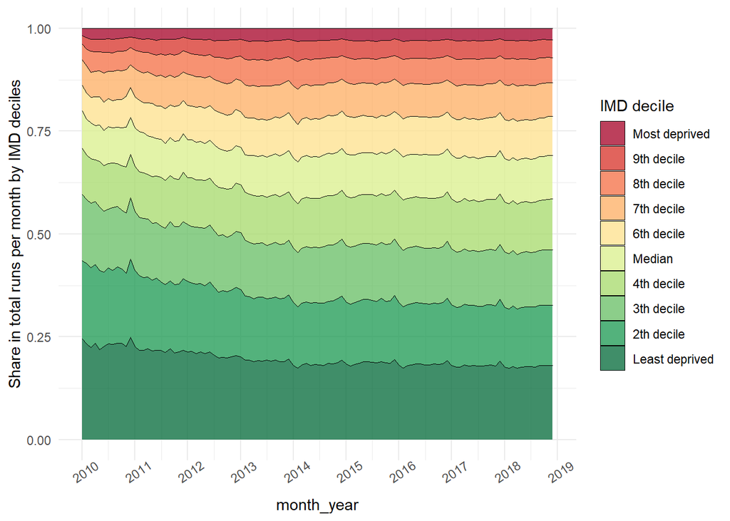

```r
# Compute the ratio between the top and bottom IMD median distance ratio
runs_by_imd_shares = dcast(data = runs_by_imd,formula = month_year ~ imd_decile,value.var = "finishers")
runs_by_imd_shares$totals = rowSums(runs_by_imd_shares[,-1])
runs_by_imd_shares2 = runs_by_imd_shares[, lapply(.SD, function(x){x/totals}), .SDcols = 2:11]
runs_by_imd_shares2$month_year = runs_by_imd_shares$month_year
runs_by_imd_shares2 = melt(runs_by_imd_shares2,id.vars = "month_year")

ggplot(runs_by_imd_shares2,aes(x=month_year,y=value,fill=variable)) +
  geom_area(col="black",size=0.2,alpha=0.75) +
  scale_fill_manual(values = imd_colors,name="IMD decile",labels=imd_labels) +
  scale_x_date(date_breaks = "1 year",date_labels = "%Y") +
  ylab("Share in total runs per month by IMD deciles") +
  theme_minimal() +
  theme(axis.text.x = element_text(angle=35))
```

#### The slope index of inequality in participation over time

```r
# max and min IMD
imd_range =  c(max(monthly_runs_by_lsoa$imd_score),min(monthly_runs_by_lsoa$imd_score))
total_pop_mean = mean(monthly_runs_by_lsoa$total_pop)

# Slope index of inequality - Example
temp = monthly_runs_by_lsoa[month_year=="2018-08", ]
lm.temp = glm(finishers ~ imd_score,data=temp,family=poisson(link="log"),offset = log(total_pop))
pred.temp = predict(lm.temp,newdata = data.frame(imd_score = imd_range,total_pop=total_pop_mean),type="response")
pred.temp.line = predict(lm.temp,
                         newdata = data.frame(imd_score = seq(imd_range[1],imd_range[2],by=-1),
                                              total_pop=total_pop_mean),
                         type="response")
tb_ratio.temp = pred.temp[2] / pred.temp[1]
tb_ratio.temp
```

```
##        2
## 30.77111
```

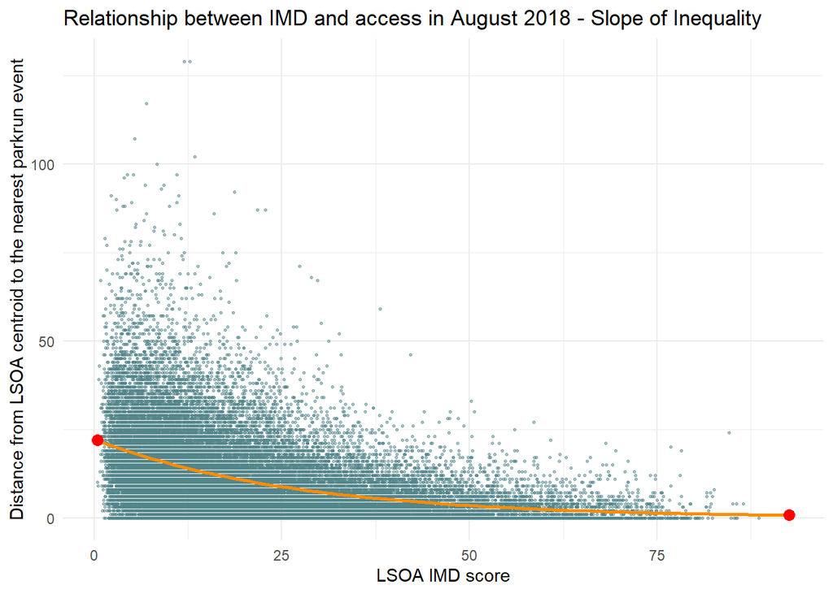

```r
ggplot() +
  geom_point(data=temp,aes(x=imd_score,y=finishers),alpha=0.5,size=0.5,col="cadetblue4") +
  geom_line(aes(x=seq(imd_range[1],imd_range[2],by=-1),y=pred.temp.line),size=1,col="darkorange") +
  # geom_smooth(data=temp,aes(x=imd_score,y=finishers),col="darkorange",method="lm",se=F) +
  geom_point(aes(x=imd_range,y=pred.temp),size=3,col="red") +
  ylab("Distance from LSOA centroid to the nearest parkrun event") +
  xlab("LSOA IMD score") +
  ggtitle("Relationship between IMD and access in August 2018 - Slope of Inequality") +
  theme_minimal()
```

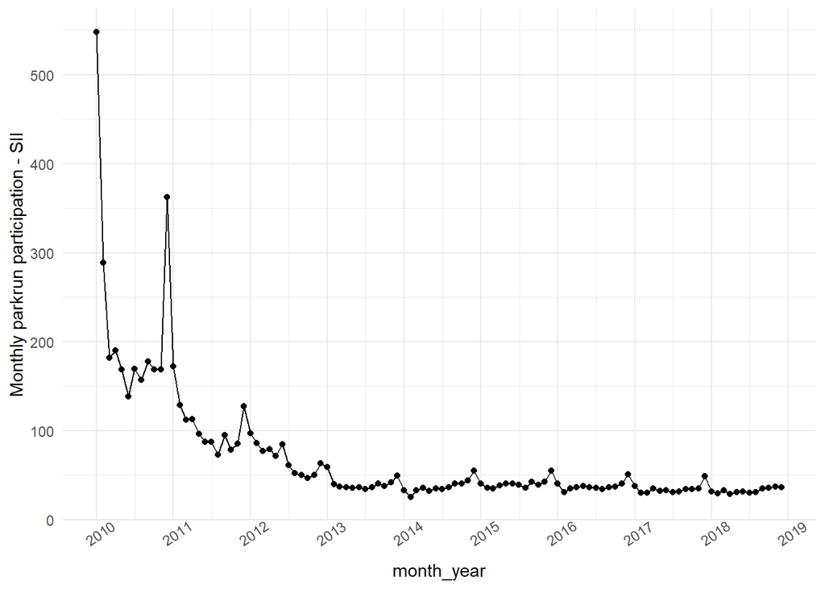

```r
# Loop over all months
uniq.months = unique(monthly_runs_by_lsoa$month_year)
si_runs_ts = c()
for(m in uniq.months){
  # cat("\r",m)
  temp = monthly_runs_by_lsoa[month_year==m, ]
  lm.temp = glm(finishers ~ imd_score,data=temp,family=poisson(link="log"),offset = log(total_pop))
  pred.temp = predict(lm.temp,newdata = data.frame(imd_score = imd_range,total_pop=total_pop_mean),type="response")
  tb_ratio.temp = pred.temp[2] / pred.temp[1]
  res.df.temp = data.frame(sii = tb_ratio.temp,month_year=m)
  si_runs_ts = rbind(si_runs_ts,res.df.temp)
}

si_runs_ts$month_year = as.Date(paste(si_runs_ts$month_year,"-01",sep=""))

ggplot(si_runs_ts,aes(x=month_year,y=sii)) +
  geom_point() +
  geom_line() +
  scale_x_date(date_breaks = "1 year",date_labels = "%Y") +
  ylab("Monthly parkrun participation - SII") +
  theme_minimal() +
  theme(axis.text.x = element_text(angle=35))
```

**Conclusion: Inital decrease in inequality (2010-2013), then stable plateau around 35(!)**

## CONCLUSION

Previous work showed that in 2018 participation in parkrun was inequitable, while access to parkrun was equitable.

However, these changes were not equitable across society. Access became increasingly inequitable, in favour of more deprived areas who had better access to begin with, from 2010 to 2017, after which stage it became slightly more equitable. While participation became more equitable from 2010 to 2013 there has been little change since then, with those in least deprived 50% of communities accounting for around 70% of the finishes.

These findings suggest that access, although a prerequisit, is not a driver of inequalities in participation. A deeper understanding of the reasons why areas with higher levels of deprivation have lower participation in parkrun is essential in order to maximize the public health benefits of parkrun.

…